# Glioblastoma scRNA-seq : tumour states and microenvironment

- Show All Code
- Hide All Code
- View Source

Synthesis and conclusion

Authors

Azzeddine ALILICHE

Anais HLUSZKO

Corentin OSTA

Published

November 4, 2026

```r
suppressPackageStartupMessages({
  library(Seurat)
  library(dplyr)
  library(ggplot2)
  library(CellChat)
})
sample.name <- "brain_DV200"

load(paste0('../data/processed_data/', sample.name, '_STATES.rda'))  # sobjFiltrd
load(paste0('../data/processed_data/', sample.name, '_TME.rda'))     # myeloid, tcells
cellchat <- readRDS(paste0('../data/processed_data/', sample.name, '_cellchat.rds'))
```

## Question

A glioblastoma contains **tumour cells**, found in several transcriptional states, and a **tumour microenvironment (TME)** dominated by macrophages. We asked : **in this tumour, which tumour states are present, what microenvironment surrounds them, and which signals might connect them ?**

## Data

- 10x Genomics public dataset *Mixture of Lung Cancer and Glioblastoma FFPE Tissues Dissociated Manually or using gentleMACS Dissociator, Multiplexed Samples, 4 Probe Barcodes* (Chromium Flex, probe-based chemistry, Cell Ranger 7.1.0).
- We analysed **one sample : the glioblastoma, manual dissociation** (probe barcode BC3). There is no replicate, so all the results describe this tumour only.

## Pipeline

| Step | Report | Main tools | Output |
| --- | --- | --- | --- |
| 1. Quality control | QC | Seurat, scDblFinder | 4005 cells kept |
| 2. Clustering & annotation | Clustering | Seurat, SingleR, GBmap label transfer, markers | 11 clusters annotated |
| 3. Malignant cells | CNV | inferCNV (chr7 gain / chr10 loss) | Malignant / normal call per cell |
| 4. Tumour states | States | Neftel et al. 2019 meta-modules, GO (g:Profiler) | MES / AC / NPC / OPC-like states |
| 5. Microenvironment | TME | Sub-clustering, markers, GO (g:Profiler) | TAM sub-populations, T cell profile |
| 6. Communication | CellChat | CellChat v2 | Ligand-receptor signals |

QC thresholds : more than 800 genes and 1000 UMI per cell, less than 10% mitochondrial reads, doublets removed with scDblFinder.

## 1. Cell types

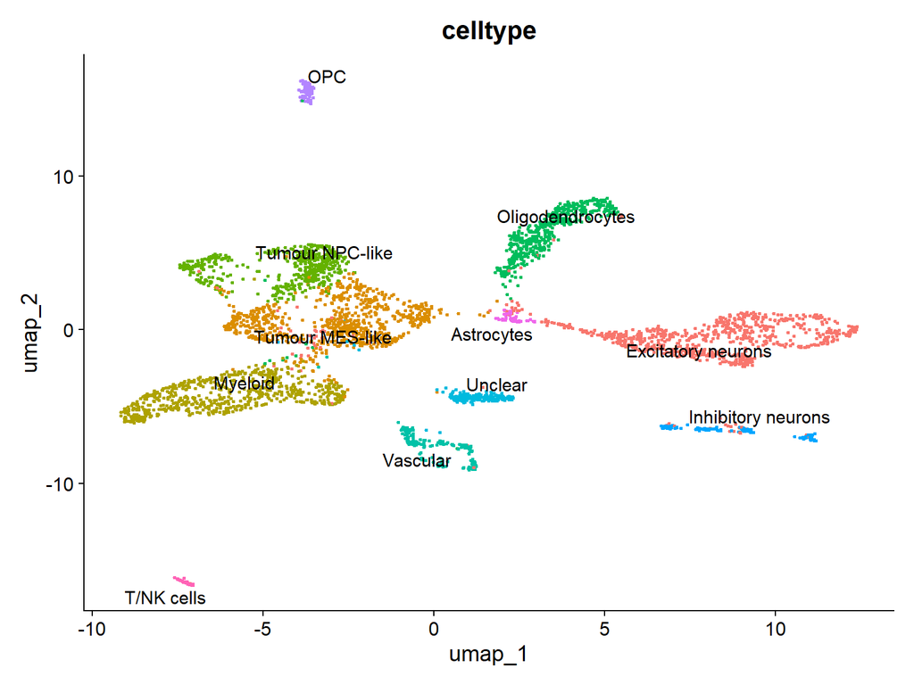

```r
DimPlot(sobjFiltrd, group.by = "celltype", label = TRUE, repel = TRUE) + NoLegend()
```

```r
sobjFiltrd@meta.data %>%
  count(celltype, name = "n") %>%
  mutate(pct = round(100 * n / sum(n), 1)) %>%
  arrange(desc(n)) %>%
  knitr::kable(col.names = c("Cell type", "n", "% of cells"))
```

| Cell type | n | % of cells |
| --- | --- | --- |
| Excitatory neurons | 813 | 20.3 |
| Tumour MES-like | 805 | 20.1 |
| Myeloid | 673 | 16.8 |
| Tumour NPC-like | 515 | 12.9 |
| Oligodendrocytes | 511 | 12.8 |
| Vascular | 177 | 4.4 |
| Unclear | 176 | 4.4 |
| Inhibitory neurons | 136 | 3.4 |
| OPC | 93 | 2.3 |
| Astrocytes | 57 | 1.4 |
| T/NK cells | 49 | 1.2 |

The sample contains tumour cells, macrophages (myeloid), vascular cells, T/NK cells and a large part of infiltrated brain tissue (neurons, oligodendrocytes, astrocytes, OPC).

## 2. Malignant cells (inferCNV)

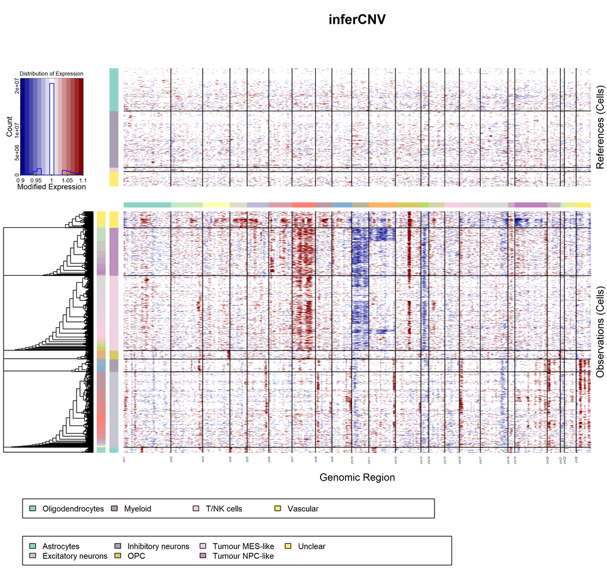

```r
knitr::include_graphics("../data/infercnv_out/infercnv.png")
```

```r
ref_groups <- c("Oligodendrocytes", "Myeloid", "T/NK cells", "Vascular")
sobjFiltrd@meta.data %>%
  mutate(group = ifelse(celltype %in% ref_groups, "Reference", "Tested")) %>%
  group_by(group, celltype) %>%
  summarise(n = n(),
            pct_malignant = round(100 * mean(cnv_status == "Malignant")),
            median_chr7 = round(median(chr7), 3),
            median_chr10 = round(median(chr10), 3),
            .groups = "drop") %>%
  arrange(desc(group), desc(pct_malignant)) %>%
  knitr::kable(col.names = c("Group", "Cell type", "n", "% malignant", "Median chr7", "Median chr10"))
```

| Group | Cell type | n | % malignant | Median chr7 | Median chr10 |
| --- | --- | --- | --- | --- | --- |
| Tested | Tumour NPC-like | 515 | 97 | 1.045 | 0.959 |
| Tested | Tumour MES-like | 805 | 76 | 1.030 | 0.974 |
| Tested | Unclear | 176 | 62 | 1.028 | 0.989 |
| Tested | OPC | 93 | 16 | 1.006 | 0.998 |
| Tested | Excitatory neurons | 813 | 2 | 1.001 | 0.997 |
| Tested | Inhibitory neurons | 136 | 1 | 1.003 | 0.997 |
| Tested | Astrocytes | 57 | 0 | 0.999 | 1.001 |
| Reference | T/NK cells | 49 | 6 | 1.003 | 1.001 |
| Reference | Vascular | 177 | 2 | 1.001 | 1.001 |
| Reference | Myeloid | 673 | 1 | 1.001 | 1.002 |
| Reference | Oligodendrocytes | 511 | 1 | 1.001 | 1.001 |

- The tumour clusters carry the **classic glioblastoma signature, chr7 gain and chr10 loss**, plus a chr13 loss and a focal chr12 gain, most likely an **MDM2 amplification** (MDM2 is highly expressed in tumour cells only).
- The OPC cluster is mostly normal, and the neurons, astrocytes and reference cells are flat.
- **1268 cells are called malignant** and used for the tumour state analysis.

## 3. Tumour states (Neftel et al. 2019)

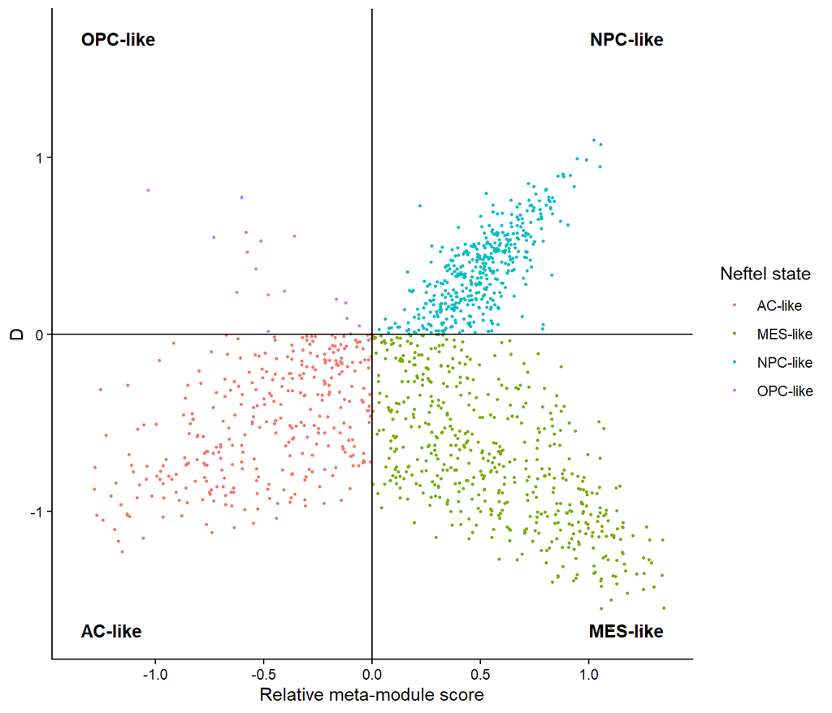

```r
tum <- sobjFiltrd@meta.data %>% filter(!is.na(neftel_state))

ggplot(tum, aes(x = neftel_x, y = neftel_y, colour = neftel_state)) +
  geom_point(size = 0.6) +
  geom_hline(yintercept = 0) + geom_vline(xintercept = 0) +
  annotate("text", x = c(-1, 1, -1, 1) * max(abs(tum$neftel_x)), y = c(1, 1, -1, -1) * max(abs(tum$neftel_y)),
           label = c("OPC-like", "NPC-like", "AC-like", "MES-like"), hjust = c(0, 1, 0, 1), fontface = "bold") +
  theme_classic() +
  labs(x = "Relative meta-module score", y = "D", colour = "Neftel state")
```

```r
tum %>%
  group_by(neftel_state) %>%
  summarise(n = n(),
            pct_tumour = round(100 * n() / nrow(tum), 1),
            pct_cycling = round(100 * mean(cycling), 1)) %>%
  arrange(desc(n)) %>%
  knitr::kable(col.names = c("Neftel state", "n", "% of tumour cells", "% cycling"))
```

| Neftel state | n | % of tumour cells | % cycling |
| --- | --- | --- | --- |
| MES-like | 510 | 40.2 | 1.8 |
| NPC-like | 413 | 32.6 | 10.4 |
| AC-like | 327 | 25.8 | 2.8 |
| OPC-like | 18 | 1.4 | 0.0 |

| State | GO enrichment (main terms) | Top marker genes |
| --- | --- | --- |
| MES-like | Response to hypoxia, angiogenesis, wound healing | ADM, ANGPTL4, NDRG1, CA12, SERPINE1, CHI3L1 |
| AC-like | Gliogenesis, glial cell differentiation | ATP1A2, BCAN, KCNJ10, AQP1 |
| NPC-like | Neurogenesis, epigenetic regulation, cell cycle | CRABP1, ONECUT2, GRIK2, CPLX1 |

- The tumour combines **three main states : MES-like, NPC-like and AC-like**. OPC-like cells are almost absent.
- **AC-like and MES-like cells form a continuum**, while NPC-like cells form a distinct group that contains most of the cycling cells.
- **The MES-like cells are hypoxic** : hypoxia is the strongest GO signal of the whole analysis.

## 4. Microenvironment

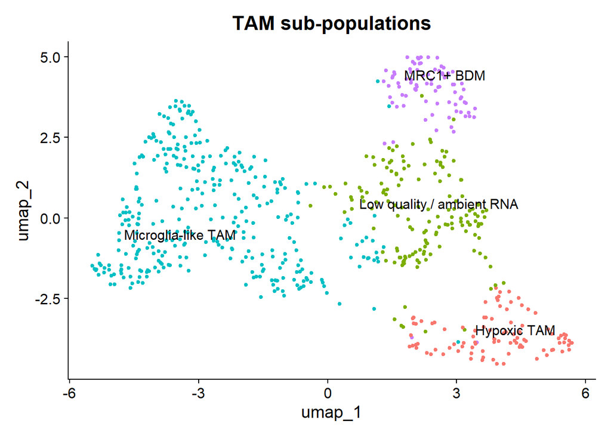

```r
DimPlot(myeloid, group.by = "tam_type", label = TRUE, repel = TRUE) + NoLegend() + ggtitle("TAM sub-populations")
```

```r
myeloid@meta.data %>%
  group_by(tam_type) %>%
  summarise(n = n(), pct_BDM_like = round(100 * mean(origin == "BDM-like"))) %>%
  arrange(desc(n)) %>%
  knitr::kable(col.names = c("TAM sub-population", "n", "% BDM-like"))
```

| TAM sub-population | n | % BDM-like |
| --- | --- | --- |
| Microglia-like TAM | 338 | 34 |
| Low quality / ambient RNA | 151 | 88 |
| Hypoxic TAM | 97 | 96 |
| MRC1+ BDM | 82 | 100 |

- About **63% of the TAMs look bone marrow-derived** (BDM), the others microglia-like.
- Three TAM sub-populations : **microglia-like TAMs**, **hypoxic TAMs** (VEGFA, ADM, SLC2A1, SPP1) and **MRC1+ BDM** (CD163, MRC1, SIGLEC1). One sub-cluster was set aside, it is made of low quality macrophages with ambient tumour RNA.
- The TAMs lean towards an **immunosuppressive profile** (CD163, SPP1, MRC1 high, IL1B and TNF low).
- **46 T cells only** : cytotoxic genes but almost no IFNG, no proliferation and exhaustion markers in part of the cells, a “cold” immune environment.

## 5. Communication between the tumour and its microenvironment

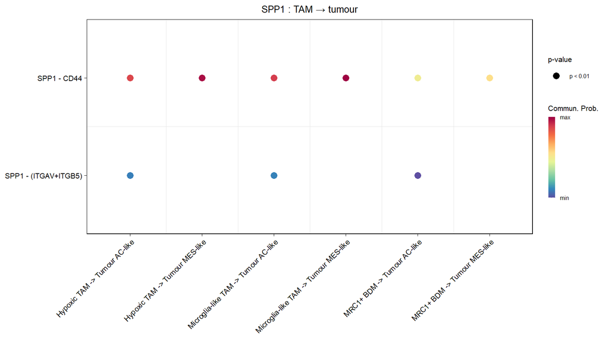

```r
netVisual_bubble(cellchat, sources.use = c("Microglia-like TAM", "Hypoxic TAM", "MRC1+ BDM"),
                 targets.use = c("Tumour MES-like", "Tumour AC-like", "Tumour NPC-like"),
                 signaling = "SPP1", remove.isolate = TRUE, angle.x = 45, title.name = "SPP1 : TAM → tumour")
```

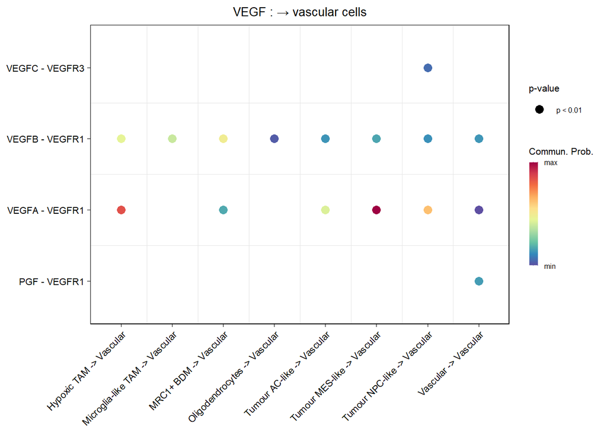

```r
netVisual_bubble(cellchat, targets.use = "Vascular", signaling = "VEGF",
                 remove.isolate = TRUE, angle.x = 45, title.name = "VEGF : → vascular cells")
```

| Hypothesis | Result |
| --- | --- |
| SPP1 → CD44 (TAM → tumour) | **Supported** : strongest TAM → tumour signal, towards MES-like and AC-like cells |
| VEGF (hypoxic niche → vessels) | **Supported** : VEGFA → FLT1, mostly from MES-like cells and hypoxic TAMs |
| OSM → OSMR (TAM → MES-like, Hara et al. 2021) | **Not detected** : OSMR on MES-like cells, but OSM low in TAMs |
| PD-L1 → PD-1 | **Not detected** : PD-L1 almost absent |
| CD47 → SIRPA | **Compatible, not tested** (not in CellChatDB) |

## Conclusion

In this glioblastoma, the inferCNV analysis confirmed the malignant cells by the classic chr7 gain and chr10 loss, with a probable MDM2 amplification. The tumour cells are found in **three main states** : NPC-like cells, which form a distinct and proliferating group, and AC-like and MES-like cells, which form a continuum, in line with the plasticity described by Neftel et al.

**Hypoxia is the common thread of the tumour-microenvironment relationship.** The MES-like tumour cells and a population of hypoxic TAMs share the same hypoxia program and probably live in the same poorly oxygenated areas. Both send pro-angiogenic VEGFA signals to the vascular cells, and the TAMs signal to the MES-like cells through **SPP1 → CD44**, an axis linked to the mesenchymal phenotype and to immunosuppression in glioma.

The microenvironment is dominated by **macrophages, mostly bone marrow-derived and immunosuppressive**, while T cells are rare and poorly active, the “cold” profile typical of glioblastoma. The OSM → OSMR mechanism proposed by Hara et al. was not detected, either a feature of this tumour or a sensitivity limit of the data.

**Model for this tumour** : a hypoxic niche in which MES-like tumour cells and hypoxic, immunosuppressive TAMs interact through SPP1 – CD44 and jointly drive angiogenesis through VEGFA, in a microenvironment with little anti-tumour immune activity.

## Limits

- **A single tumour, a single sample** : no biological replicate, the results are descriptive and generate hypotheses, they cannot be generalised to glioblastoma. Cells of one sample are not independent, so the p-values (DE, GO) are inflated.
- **Dissociated FFPE tissue** : the proportions of cell types depend on the dissociation, and ambient RNA from tumour cells contaminates other cells (e.g. GFAP in macrophages).
- **Probe-based chemistry (Flex)** : only the genes of the probe panel are measured, lowly expressed genes (e.g. OSM) can be missed.
- **Predictions from RNA** : malignant calls (inferCNV), states (module scores) and communications (CellChat) are inferred from expression, not measured directly. Spatial proximity is unknown.

## Perspectives

- Analyse the second glioblastoma sample of the dataset (gentleMACS dissociation) to check that the results are not driven by the dissociation method.
- Confirm the hypoxic niche and the SPP1 – CD44 axis on tissue (immunostaining, spatial transcriptomics), and the MDM2 amplification on DNA.
- Compare with a multi-patient cohort (e.g. GBmap) to see whether this MES / hypoxic profile is frequent.

## References

- Neftel C. *et al.* An integrative model of cellular states, plasticity, and genetics for glioblastoma. *Cell* 178, 835-849 (2019).
- Hara T. *et al.* Interactions between cancer cells and immune cells drive transitions to mesenchymal-like states in glioblastoma. *Cancer Cell* 39, 779-792 (2021).
- Ruiz-Moreno C. *et al.* Charting the single-cell and spatial landscape of IDH-wild-type glioblastoma with GBmap. *Neuro-Oncology* (2025).
- Tickle T. *et al.* inferCNV of the Trinity CTAT Project (Broad Institute).
- Jin S. *et al.* CellChat for systematic analysis of cell-cell communication from single-cell transcriptomics. *Nature Protocols* (2024).
- Hao Y. *et al.* Dictionary learning for integrative, multimodal and scalable single-cell analysis (Seurat v5). *Nature Biotechnology* (2024).